# IntroDS - Tarea 1

## Consideraciones en la entrega

- La tarea debe ser enviada en forma de script, por ejemplo `mi_archivo.R`.
- Al comienzo del script deben identificarse los integrandes del grupo, máximo 3.
- El script debe generar, en orden, los resultados solicitados. Agregando en forma de comentarios (`# los comentarios parten con #`) cualquier respuesta o información adicional que se requiera.
- El script debe ser reproducible. El archivo .R debe poder ejecutarse sin problemas por cualquier persona con el programa, siguiendo el orden lógico requerido para ello.
- La fecha de entrega es domingo 3 julio 2022. Por día se baja un punto.

## Datos a utilizar

Los datos con los cuales trabajaremos corresponden a 4,454 ventas de productos financieros. Para cada operacion se tienen distintas variables medidas/observadas al momento del otorgamiento.

Los datos están en la siguiente url:

https://github.com/jbkunst/usach-ingemat-intro-elementos-ds-202201/raw/main/data/datos_creditos.csv

Dentro de los datos se encuentra la columna `estado`, la cual indica si en el futuro el cliente dejó de pagar su deuda: `bueno` para los clientes que pagaron la deuda sin entrar en morosidad o `malo` para quienes quedaron morosos en algún momento.

De forma particular la cantidad de clientes `buenos` y `malos` considerando todos los registros disponibls se puede obtener con:

```r
datos |>
  count(estado)
```

```
## # A tibble: 2 × 2
##   estado     n
##   <chr>  <int>
## 1 bueno   3200
## 2 malo    1254
```

Se define la *tasa de clientes malos* como la cantidad de clientes malos sobre el conjunto de clientes considerados.

## Instrucciones/Preguntas

1. ¿Cuál es la tasa de clientes malos al considerar todos los registros?

```r
library(tidyverse)

url <- "https://github.com/jbkunst/usach-ingemat-intro-elementos-ds-202201/raw/main/data/datos_creditos.csv"
datos <- read_csv(url)
glimpse(datos)
```

```
## Rows: 4,454
## Columns: 14
## $ estado      <chr> "bueno", "bueno", "malo", "bueno", "bueno", "bueno", "buen…
## $ antiguedad  <dbl> 9, 17, 10, 0, 0, 1, 29, 9, 0, 0, 6, 7, 8, 19, 0, 0, 15, 33…
## $ vivienda    <chr> "alquila", "alquila", "propietario", "alquila", "alquila",…
## $ plazo       <dbl> 60, 60, 36, 60, 36, 60, 60, 12, 60, 48, 48, 36, 60, 36, 18…
## $ edad        <dbl> 30, 58, 46, 24, 26, 36, 44, 27, 32, 41, 34, 29, 30, 37, 21…
## $ estadocivil <chr> "casado", "viudo", "casado", "soltero", "soltero", "casado…
## $ registros   <chr> "no", "no", "sí", "no", "no", "no", "no", "no", "no", "no"…
## $ trabajo     <chr> "freelance", "fijo", "freelance", "fijo", "fijo", "fijo", …
## $ gastos      <dbl> 73, 48, 90, 63, 46, 75, 75, 35, 90, 90, 60, 60, 75, 75, 35…
## $ ingresos    <dbl> 129, 131, 200, 182, 107, 214, 125, 80, 107, 80, 125, 121, …
## $ activos     <dbl> 0, 0, 3000, 2500, 0, 3500, 10000, 0, 15000, 0, 4000, 3000,…
## $ deuda       <dbl> 0, 0, 0, 0, 0, 0, 0, 0, 0, 0, 0, 0, 2500, 260, 0, 0, 0, 20…
## $ cantidad    <dbl> 800, 1000, 2000, 900, 310, 650, 1600, 200, 1200, 1200, 115…
## $ precio      <dbl> 846, 1658, 2985, 1325, 910, 1645, 1800, 1093, 1957, 1468, …
```

```r
summarise(datos, mean(estado == "malo"))
```

```
## # A tibble: 1 × 1
##   `mean(estado == "malo")`
##                      <dbl>
## 1                    0.282
```

1. ¿Cuántos clientes poseen un trabajo freelance y estado civil divorciado?

```r
datos |>
  filter(trabajo == "freelance", estadocivil == "divorciado") |>
  nrow()
```

```
## [1] 7
```

1. ¿Cual es la tasa de clientes malos en el subconjunto de clientes anterior?

```r
datos |>
  filter(trabajo == "freelance", estadocivil == "divorciado") |>
  summarise(mean(estado == "malo"))
```

```
## # A tibble: 1 × 1
##   `mean(estado == "malo")`
##                      <dbl>
## 1                    0.143
```

1. De acuerdo a los datos, que porcentaje de cliente posee más gastos que ingresos.

```r
datos |>
  filter(gastos > ingresos) |>
  nrow()
```

```
## [1] 197
```

```r
datos |>
  group_by(gastos > ingresos) |>
  summarise(n = n()) |>
  mutate(p = 100 * n/sum(n))
```

```
## # A tibble: 3 × 3
##   `gastos > ingresos`     n     p
##   <lgl>               <int> <dbl>
## 1 FALSE                3876 87.0
## 2 TRUE                  197  4.42
## 3 NA                    381  8.55
```

1. Genere un gráfico de dispersión entre edad y antiguedad ¿Qué se observa?

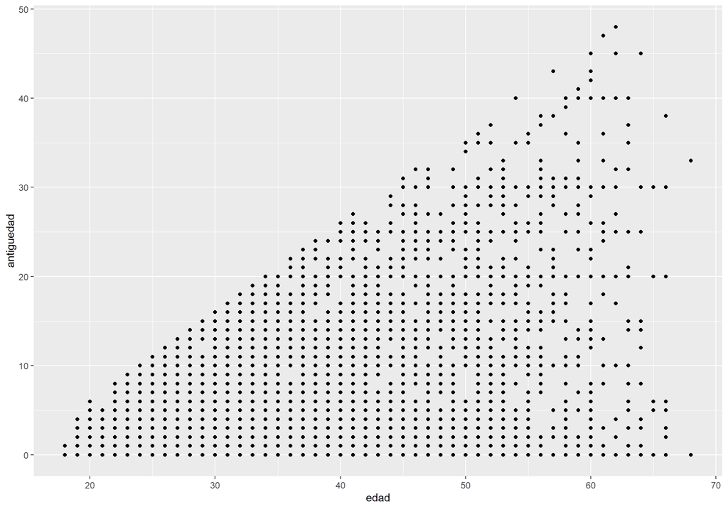

```r
ggplot(datos) +
  geom_point(aes(edad, antiguedad))
```

1. Genere un gráfico que muestre de mejor manera la relación entre edad y antiguedad.

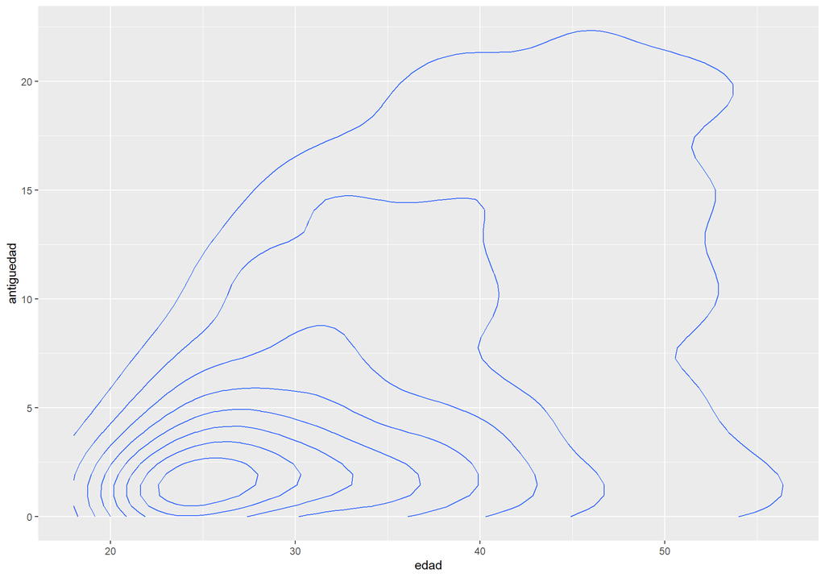

```r
ggplot(datos) +
  geom_density_2d(aes(edad, antiguedad))
```

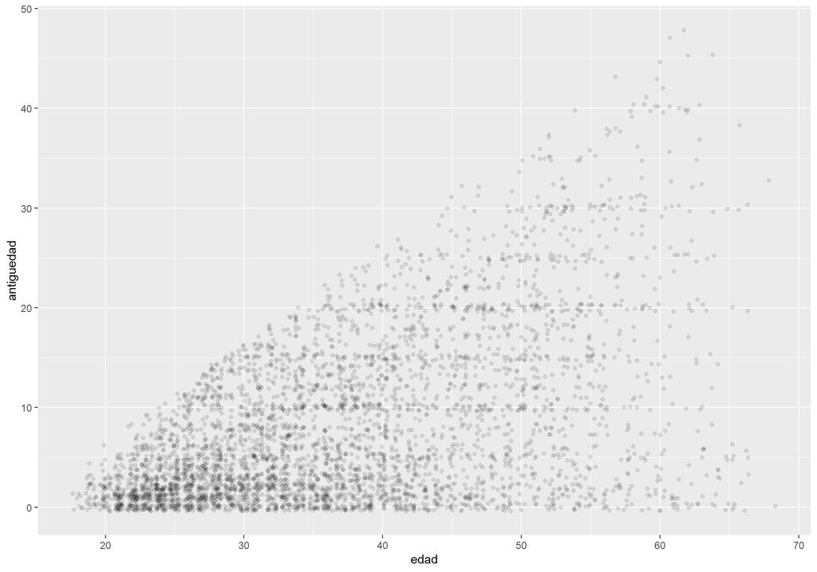

```r
ggplot(datos) +
  geom_point(aes(edad, antiguedad), alpha = 0.1, position = position_jitter())
```

1. Obtenga la tasa de clientes malos de acuerdo a las categorías de la columna tipo de trabajo (`trabajo`). Argumente por que este resultado es esperable en el contexto bancario.

```r
datos |>
  group_by(trabajo) |>
  summarise(mean(estado == "malo"))
```

```
## # A tibble: 5 × 2
##   trabajo        `mean(estado == "malo")`
##   <chr>                             <dbl>
## 1 fijo                              0.207
## 2 freelance                         0.325
## 3 otros                             0.398
## 4 tiempo parcial                    0.600
## 5 <NA>                              1
```

1. Genere un boxplot (https://tinyurl.com/ycxh2wnj) de edad según la variable estado. Explique que observa en le contexto de los datos utilizados.

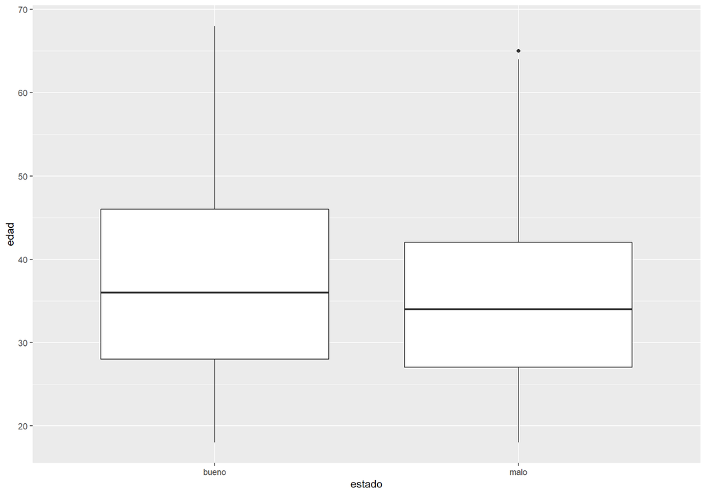

```r
ggplot(datos) +
  geom_boxplot(aes(estado, edad))
```

1. Genere un gráfico de dispersión entre edad versus el monto del crédito solicitado (`cantidad`); agregue además una capa de suavizamiento con `geom_smooth`. Comente lo que observa y como ayuda la línea generada para entender como se relacionan los datos.

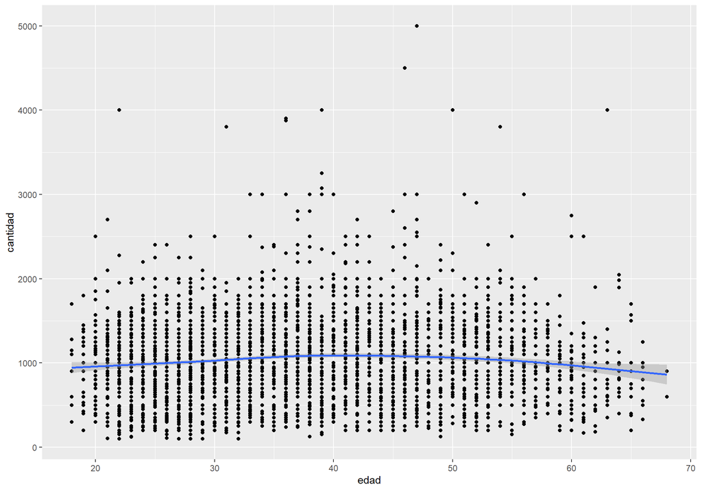

```r
ggplot(datos) +
  geom_point(aes(edad, cantidad)) +
  geom_smooth(aes(edad, cantidad))
```